안녕하세요? 웹R(web-r.org)의 운영자 [“문건웅”](http://www.doctorsnews.co.kr/news/articleView.html?idxno=103653)입니다. 웹에서 하는 R 구조방정식 앱을 소개합니다. 이 앱은 [“의학논문 작성을 위한 R통계와 그래프”](http://www.aladin.co.kr/shop/wproduct.aspx?ISBN=8955661797)(한나래출판사,2015) 및 [“웹에서 클릭만으로 하는 R 통계분석”](http://www.aladin.co.kr/shop/wproduct.aspx?ItemId=66714863)의 저자인 문건웅(cardiomoon@gmail.com)이 R과 shiny 를 이용하여 만들었고 현재 “웹에서 하는R 통계분석” 서버인 web-r.org를 통해 운영되고 있습니다.

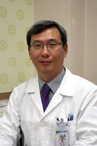

[figure not shown]

[figure not shown]

이 앱을 만들 때 김계수 교수님의 [“R-구조방정식 모델링”](http://www.aladin.co.kr/shop/wproduct.aspx?ItemId=71144910)(한나래,2015) 책에서 많은 도움을 얻었습니다. 또한 경북대학교 사회복지학과 황성동 교수님으로부터 많은 도움을 받았슴을 밝힙니다.

lavaan 패키지를 이용한 구조방정식 분석에 관하여는 다음 문서를 참조하십시요.

http://lavaan.ugent.be/tutorial/index.html

한글로 된 책을 찾으시는 분은 김계수 교수님의 책을 참조하시기 바랍니다.

[figure not shown]

이 앱에서는 R의 `lavaan` 패키지를 사용하여 구조방정식 분석을 시행하였으며 구조방정식의 시각화에는 `semPlot` 패키지를 사용하였습니다. 그 외에 `rhandsontable` 패키지와 `ReporteRs` 패키지도 사용하였습니다. 혹 버그나 건의사항 등이 있을 경우 `웹에서 하는 R 통계` (web-r.org)서버에 접속하셔서 게시판에 글 남겨주시면 감사하겠읍니다. 패키지에 관한 내용은 다음 싸이트를 참조하십시요.

R package lavaan: [“lavaan 패키지”](https://cran.r-project.org/web/packages/lavaan/index.html)

R package semPlot: [“semPlot 패키지”](https://cran.r-project.org/web/packages/semPlot/index.html)

R package rhandsontable: [“rhandsontable 패키지”](https://cran.r-project.org/web/packages/rhandsontable/index.html)

R package ReporteRs: [“ReporteRs 패키지”](https://cran.r-project.org/web/packages/ReporteRs/index.html)

웹 R운영자 문 건웅 드림